# GROW Molecular Formula Relationships

RED

2023-11-22

As opposed to the other Rmarkdown which was looking at relationships from various cheminformatic derived information sets, this script is going directly correlate molecular formula intensities/relative intensities to the 7 carbon use classes. In order to accomplish this, we need to ensure that our intensities are normalized - as such, we will be using the pMartR package to identity the best normalization approach (Thompson et al., 2021 - Rapid Comm. Mass. Spec.).

Given the sensitivity of this approach, I wanted it to be broken out into it’s own Rmarkdown rather than in the larger analytical one; this relies on the merged dataset generated by the other Rmarkdown, however.

https://analyticalsciencejournals.onlinelibrary.wiley.com/doi/epdf/10.1002/rcm.9068

## Setup

Loading packages and whatnot

## Loading

Loading in the data

```r
# set working directory (redunant)
setwd( "~/Documents/PNNL Analyses/GROW Paper/")

# load in merged data
data = read.csv("Merged_S19S_Wat_8.12_Data.csv")
mol = read.csv("Merged_S19S_Wat_8.12_Mol.csv")

# load in metadata
meta = read_xlsx("Table S1 - S19S Metadata.xlsx")

# load in carbon use
carbon.use = read_xlsx("carbon_usage.xlsx")
```

## SPANS and normalization

This section will use SPANS to identify the best normalization approach for this dataset and then apply the selected normalization.

```r
# convert to pmartR
edata = data
emeta = mol
fdata = meta

# pmartR object
pmartR.obj = as.pepData(
  e_data = edata,
  f_data = fdata,
  e_meta = emeta,
  edata_cname = "X",
  fdata_cname = "ID",
  emeta_cname = "X",
  data_scale = "abundance",
  data_types = "Negative Ion"
)
```

```
## 1022717 instances of 0 have been replaced with NA
```

```r
# setting grouping (might be an issue...)
pmartR.obj = group_designation(pmartR.obj, main_effects = "ID")

# convert to log
attr(pmartR.obj, 'data_info')$data_scale = "log"

# run SPANS
spans.res = spans_procedure(pmartR.obj)
```

```
## [1] "Finished creating background distribution, moving to method candidate selection"
## [1] "Finished method candidate selection, proceeding to score selected methods."
## [1] "Finished scoring selected methods"
```

```r
# clean up
rm(edata, emeta, fdata)

### SPANS revealed nothing useful due to experimental design.
### Proceeding with TSS.

# selecting assigned formulas only
data = data[!is.na(mol$MolForm),]
mol = mol[!is.na(mol$MolForm),]

# relative intensity
data = as.data.frame(
  apply(data.frame(data, row.names = 1), 2, function(x) (x/sum(x))*100)
)
```

Well, I was unaware of this requirement for SPANS - it requires an a priori defined grouping variable which we do not have in this situation. We might be able to revisit this if we want to normalize within something defined a posteriori (like stream order), so I’m leaving the code here. With this in mind, I’ll be normalizing using TSS (e.g., relative intensity) for the assigned formulas only.

I might revisit the normalization with the “pre-merged” data at a later date.

## Molecular Formula-to-Guild Relationships

This section is running the Spearman correlations comparing each guild to each molecular formula. I’m a bit worried that the sheer number of pairwise comparisons is going to destroy any statistical power that we have, but we will see…

```r
# select only assigned formulas
data = data[!is.na(mol$MolForm),]
mol = mol[!is.na(mol$MolForm),]

# removing duplicate molecular formulas
# some peaks can be assigned the same formula
data = data %>% mutate(MolForm = mol$MolForm) %>%
  group_by(MolForm) %>%
  summarise_all(.funs = "sum")
data = data.frame(data, row.names = 1)
mol = mol[!duplicated(mol$MolForm),]

# ensuring identical order
data = data[order(row.names(data)),]
mol = mol[order(mol$MolForm),]

# confirm matching data and mol
if(!identical(row.names(data), mol$MolForm)){
  stop("The FTICR-MS data objects do not having matching masses.")
}

# preparing objects for correlation
corr.data = t(data)
corr.guild = carbon.use %>%
  pivot_wider(names_from = Guild, values_from = abund)
corr.guild[is.na(corr.guild)] = 0
corr.guild = as.matrix(data.frame(corr.guild, row.names = 1, check.names = F))

# ensuring matching objects
corr.data = corr.data[which(row.names(corr.data) %in% row.names(corr.guild)),]
corr.data = corr.data[order(row.names(corr.data)),]
corr.guild = corr.guild[order(row.names(corr.guild)),]

# running correlations
molform_stats = rcorr(corr.guild, corr.data, type = "spearman")

# removing molform self-correlations
molform_stats$r = molform_stats$r[,-which(colnames(molform_stats$r) %in% colnames(corr.data))]
molform_stats$r = molform_stats$r[-which(row.names(molform_stats$r) %in% colnames(corr.guild)),]

molform_stats$P = molform_stats$P[,-which(colnames(molform_stats$P) %in% colnames(corr.data))]
molform_stats$P = molform_stats$P[-which(row.names(molform_stats$P) %in% colnames(corr.guild)),]

# creating finalized correlation object
rho = data.frame(molform_stats$r, check.names = F) %>%
  rownames_to_column("MolForm") %>%
  gather(Guild, rho, -MolForm)
pval = data.frame(molform_stats$P, check.names = F) %>%
  rownames_to_column("MolForm") %>%
  gather(Guild, pvalue, -MolForm)
final_stats = rho %>% left_join(pval, by = c("MolForm", "Guild"))

# remove failed correlations (likely both abundances = 0 or invariant)
final_stats = final_stats[!is.na(final_stats$pvalue),]

# p-value adjustment
final_stats$padj = p.adjust(final_stats$pvalue, method = "fdr")

# clean-up
rm(corr.data, corr.guild, molform_stats)

# write stats
write.csv(final_stats, "Correlations/Guild-MolForm_Relationships.csv",
          quote = F)
```

# Looking at the results, briefly…

This section is just giving us a glimpse at the significant relationships - nothing too deep.

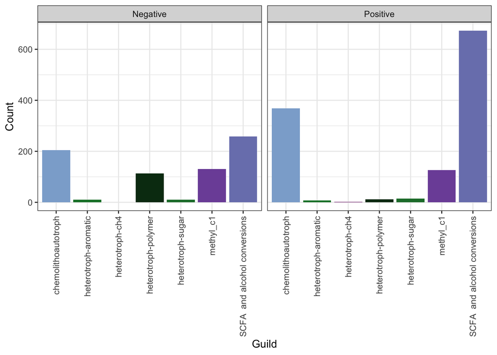

```r
# Counting significant relationships by guild
final_stats %>% filter(padj < 0.05) %>%
  mutate(Direction = case_when(rho > 0 ~ "Positive",
                               rho < 0 ~ "Negative")) %>%
  group_by(Guild, Direction) %>%
  summarise(Count = n()) %>%
  ggplot(aes(x = Guild, y = Count))+
  geom_bar(stat = "identity", aes(fill = Guild))+
  scale_fill_manual(values = color)+
  facet_grid(.~Direction)+
  theme_bw()+
  theme(legend.position = "none",
        axis.text.x = element_text(angle = 90, hjust = 1, vjust = 0.5))
```

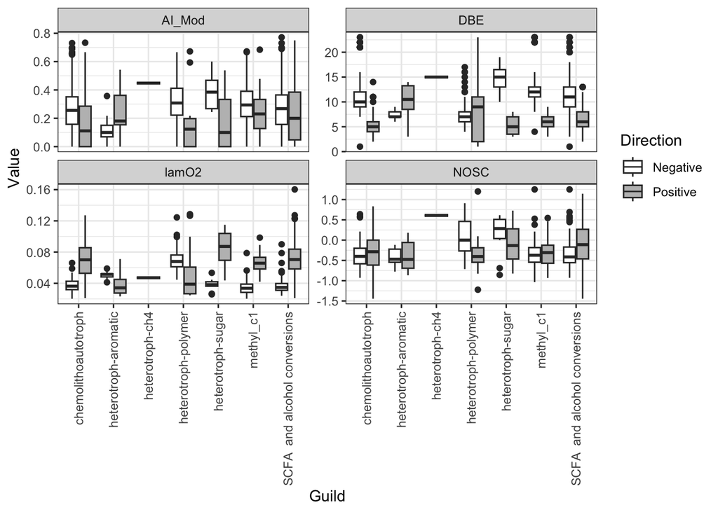

```r
### generating mol object describing each guild relationships
# calculating new boundary sets
mol$bs_johnston = johnston_set(mol)
mol$bs_roebuck = roebuck_set(mol)

# calculate lambda
get_comp = get_compositions(mol) # lambda requires specific elcomp formulation
lambda = as.data.frame(get_lambda(get_comp$chemical_compositions)) # calc lambda

# name lambda object
names <- rep("", 62)
names[1:12] <- c("delGcox0","delGd0","delGcat0","delGan0","delGdis0","lambda0",
                 "delGcox","delGd","delGcat","delGan","delGdis","lambda")
stoich_colnames <- c("donor","h2o","hco3","nh4","hpo4","hs","h","e","acceptor","biom")
stoich_types <- c("stoichD","stoichA","stoichCat","stoichAn","stoichMet")

for (i in 1:length(stoich_types)) {
  names[((i-1)*10+13):(i*10+12)] <- array(sapply(stoich_types[i], paste, stoich_colnames, sep="_"))
}

colnames(lambda) <- names

# rearrange lambda
lambda['MolForm'] <- get_comp$formulas
lambda = as.data.frame(lambda[,c("MolForm", "delGcox0", "delGcox", "lambda0", "lambda", "delGd0", "delGd")])
colnames(lambda) = c("MolForm","delGcox0PerCmol","delGcoxPerCmol", "lamO20","lamO2","delGd0","delGd")
lambda = lambda[!duplicated(lambda$MolForm),]

# add lamba to mol
mol = mol %>% left_join(lambda, by = "MolForm")

# cleanup
rm(names, stoich_colnames, stoich_types, get_comp, lambda)

# empty object
guild_mol = NULL

# looping through guilds to select molforms
for(curr.guild in unique(final_stats$Guild)){
  # identify significant
  temp = final_stats[final_stats$padj < 0.05,]

  # identify molforms
  temp.pos = temp$MolForm[which(temp$Guild %in% curr.guild &
                                  temp$rho > 0)]
  temp.neg = temp$MolForm[which(temp$Guild %in% curr.guild &
                                  temp$rho < 0)]

  # select molforms from mol
  if(length(temp.pos) == 1|length(temp.neg) == 1){
    temp = data.frame(mol[which(mol$MolForm %in% c(temp.pos, temp.neg)),],
                      Direction = case_when(length(temp.pos) == 1 ~ "Positive",
                                            length(temp.neg) == 1 ~ "Negative"),
                      check.names = F)
  } else {
    temp = data.frame(mol[which(mol$MolForm %in% temp.pos),],
                      Direction = "Positive", check.names = F)
    temp = rbind(temp,
                 data.frame(mol[which(mol$MolForm %in% temp.neg),],
                            Direction = "Negative", check.names = F))
  }

  # associate formulas with guild
  temp$Guild = curr.guild

  # add into final object
  guild_mol = rbind(guild_mol, temp)

  # clean up
  rm(temp, temp.pos, temp.neg)
}

# plotting metrics
plot1 = guild_mol %>%
  select(AI_Mod, DBE, NOSC, lamO2, Guild, Direction) %>%
  gather(Variable, Value, -Guild, -Direction) %>%
  ggplot(aes(x = Guild, y = Value))+
  geom_boxplot(aes(fill = Direction))+
  scale_fill_manual(values = c("white", "gray"))+
  facet_wrap(.~Variable, scales = "free_y")+
  theme_bw()+
  theme(axis.text.x = element_text(angle = 90, hjust = 1, vjust = 0.5))
plot1
```

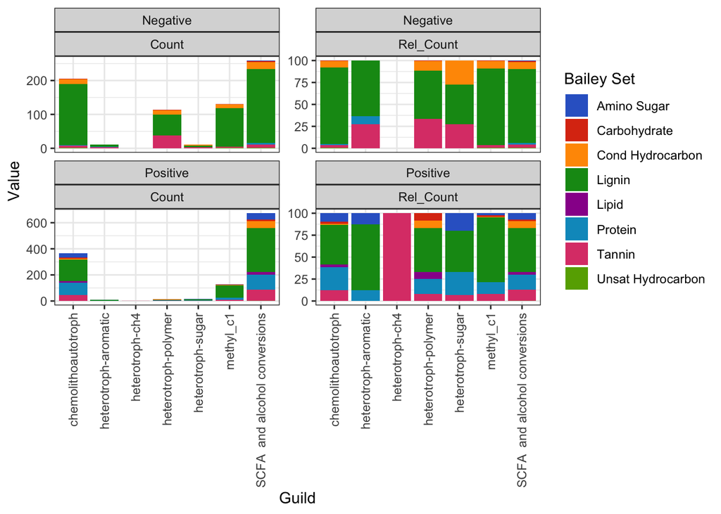

```r
# plotting bailey boundary set
plot2 = guild_mol %>%
  group_by(Guild, bs2_class, Direction) %>%
  summarise(Count = n()) %>%
  ungroup() %>% group_by(Guild, Direction) %>%
  mutate(Rel_Count = (Count/sum(Count))*100) %>%
  gather(Variable, Value, -Guild, -bs2_class, -Direction) %>%
  ggplot(aes(x = Guild, y = Value))+
  geom_bar(stat = "identity", aes(fill = bs2_class))+
  scale_fill_gdocs(name = "Bailey Set")+
  facet_wrap(Direction~Variable, scales = "free_y")+
  theme_bw()+
  theme(axis.text.x = element_text(angle = 90, hjust = 1, vjust = 0.5))
plot2
```

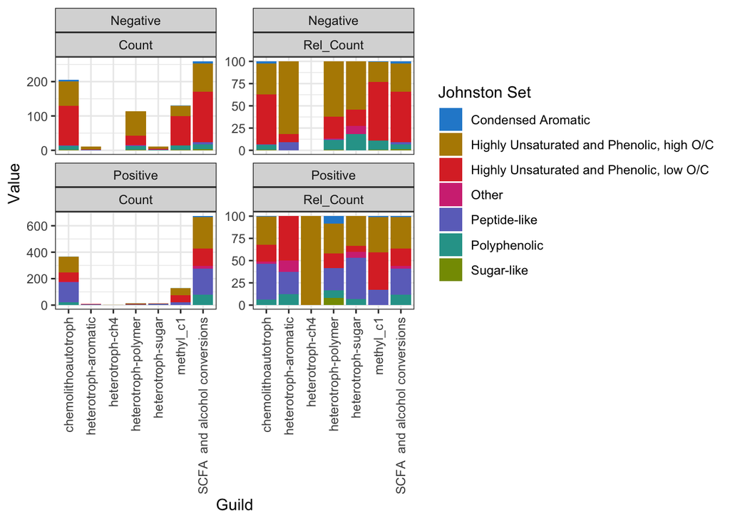

```r
# plotting johnston boundary set
plot3 = guild_mol %>%
  group_by(Guild, bs_johnston, Direction) %>%
  summarise(Count = n()) %>%
  ungroup() %>% group_by(Guild, Direction) %>%
  mutate(Rel_Count = (Count/sum(Count))*100) %>%
  gather(Variable, Value, -Guild, -bs_johnston, -Direction) %>%
  mutate(bs_johnston = case_when(is.na(bs_johnston) ~ "Other",
                                 .default = bs_johnston)) %>%
  ggplot(aes(x = Guild, y = Value))+
  geom_bar(stat = "identity", aes(fill = bs_johnston))+
  scale_fill_solarized(name = "Johnston Set")+
  facet_wrap(Direction~Variable, scales = "free_y")+
  theme_bw()+
  theme(axis.text.x = element_text(angle = 90, hjust = 1, vjust = 0.5))
plot3
```

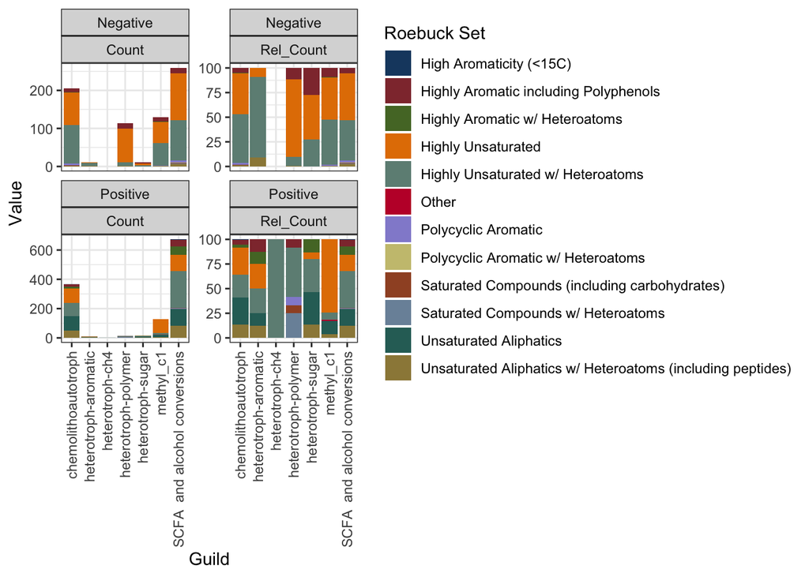

```r
# plotting roebuck boundary set
plot4 = guild_mol %>%
  group_by(Guild, bs_roebuck, Direction) %>%
  summarise(Count = n()) %>%
  ungroup() %>% group_by(Guild, Direction) %>%
  mutate(Rel_Count = (Count/sum(Count))*100) %>%
  gather(Variable, Value, -Guild, -bs_roebuck, -Direction) %>%
  mutate(bs_roebuck = case_when(is.na(bs_roebuck) ~ "Other",
                                 .default = bs_roebuck)) %>%
  ggplot(aes(x = Guild, y = Value))+
  geom_bar(stat = "identity", aes(fill = bs_roebuck))+
  scale_fill_stata(name = "Roebuck Set")+
  facet_wrap(Direction~Variable, scales = "free_y")+
  theme_bw()+
  theme(axis.text.x = element_text(angle = 90, hjust = 1, vjust = 0.5))
plot4
```

```r
# writing plots
ggsave("Figures/MolForm-Relationships_Metrics.pdf", plot1,
       height = 12, width = 12)
ggsave("Figures/MolForm-Relationships_Bailey.pdf", plot2,
       height = 12, width = 12)
ggsave("Figures/MolForm-Relationships_Johnston.pdf", plot3,
       height = 12, width = 12)
ggsave("Figures/MolForm-Relationships_Roebuck.pdf", plot4,
       height = 12, width = 12)
```